# Спецификация к Лабораторным работам №2-4

# (Вариант 22)

## Абстракция А0

### 1. Постановка задачи (ПЗ).

#### Задание:

Написать программу обработки одномерного массива в соответствии с условием.

#### Условие:

При заданных $X_1, X_2, …, X_n$ сформировать массив элементов $Y_1, Y_2, …, Y_n$ по правилу:

$ Y_i = \begin{cases} 1 - sin \ X_i \ | \ X_i > 0 \\ 1 - cos \ X_i \ | \ X_i \leq 0 \end{cases} (1)$.

При этом подсчитать число неотрицательных $ X_i $.

```python
%%latex
$
Y_i =
\begin{cases}
1 - sin \ X_i \ | \ X_i > 0 \\
1 - cos \ X_i \ | \ X_i \leq 0
\end{cases}
( 1 )
$
```

$ Y_i = \begin{cases} 1 - sin \ X_i \ | \ X_i > 0 \\ 1 - cos \ X_i \ | \ X_i \leq 0 \end{cases} ( 1 ) $

### 2. Уточненная постановка задачи.

Дан одномерный вещественный массив X из n (0 < n ≤ 20) элементов.

Найти

- Y – одномерный вещественный массив, элементы которого подсчитаны по правилу (1);
- c – количество неотрицательных элементов массива X.

### 3. Пример с иллюстрацией.

```
                    Лаб.2
Количество элементов массива X (n): 20
Массив X:
-360
-315
-270
-225
-180
-135
-90
-60
-45
-30
0
30
45
60
90
135
180
225
270
315
=============================================
Массив Y:
0.0
0.292893
1.0
1.707107
2.0
1.707107
1.0
0.5
0.292893
0.133975
0.0
0.5
0.292893
0.133975
0.0
0.292893
1.0
1.707107
2.0
1.707107

Количество неотрицательных элементов массива X (с): 10
```

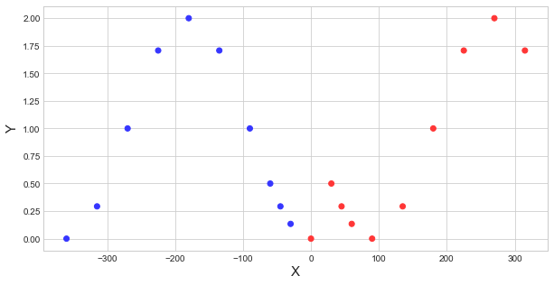

```python
import pylab as plt
import numpy
%matplotlib inline

plt.style.use('seaborn-whitegrid')

def f(x):
    if x > 0:
        return 1 - numpy.sin(x * numpy.pi / 180.)
    else:
        return 1 - numpy.cos(x * numpy.pi / 180.)


print(20*' '+'Лаб.2')
X = []
n = int(input('Количество элементов массива X (n): '))

if (n < 1 or n > 20):
    if n < 1:
        print('Некорректное n: n<1')
    else:
        print('Некорректное n: n>20')
else:
    print('Массив X:')
    for i in range(n):
        X.append(float(input()))

    X = numpy.array(X)
    print(45*'=')

    Y = numpy.array([f(x) for x in X])
    c = numpy.where(X>=0)[0].shape[0]
    colors = numpy.where(X>=0, '#ff3636', '#3636ff')

    print('Массив Y:')
    for i in range(n): print(round(Y[i], 6))
    print('\nКоличество неотрицательных элементов массива X (с):', c)

    plt.figure(figsize=(10,5))
    plt.scatter(X, Y, c=colors)
    plt.xlabel('X', fontsize=15); plt.ylabel('Y', fontsize=15);
```

```python
X.astype('int16')
```

```
array([-360, -315, -270, -225, -180, -135,  -90,  -60,  -45,  -30,    0,
         30,   45,   60,   90,  135,  180,  225,  270,  315], dtype=int16)
```

```python
Y
```

```
array([0.        , 0.29289322, 1.        , 1.70710678, 2.        ,
       1.70710678, 1.        , 0.5       , 0.29289322, 0.1339746 ,
       0.        , 0.5       , 0.29289322, 0.1339746 , 0.        ,
       0.29289322, 1.        , 1.70710678, 2.        , 1.70710678])
```

### 4. Таблица данных

[output not shown]

*! в Delphi выход из цикла с 1 до 20 с шагом +1 происходит при значении 21, из цикла с 20 до 1 – при 0*

### 5. Входная форма

- обр 1.1 Количество элементов массива X (n):
- обр 1.2
- обр 2.1 Массив X:
- обр 2.2 $ < X[1] > \\ < X[2] > \\ … \\ < X[n] > $

### 6. Выходная форма

- обр 3 Лаб. 2
- обр 4 Количество элементов массива X (n): $< n >$
- обр 5.1 Массив X:
- обр 5.2 $ < X[1] > \\ < X[2] > \\ … \\ < X[n] > $
- обр 6.1 Массив Y:
- обр 6.2 $ < Y[1] > \\ < Y[2] > \\ … \\ < Y[n] > $
- обр 7 Количество неотрицательных элементов массива X (с): $< c >$

### 7. Аномалии

| № | Описание | Условие возникновения | Реакция на аномалию |
| --- | --- | --- | --- |
| 1 | n меньше минимально допустимого значения | n<1 | Сообщение: «Некорректное n: n<1» (обр.А1) |
| - | - | - | Действие: Завершение работы программы |
| 2 | n больше максимально допустимого значения | n>20 | Сообщение: «Некорректное n: n>20» (обр.А1) |
| - | - | - | Действие: Завершение работы программы |

### 8. Функциональные тесты

| Исходные данные | - | Результаты | - | - | Тест № |
| --- | --- | --- | --- | --- | --- |
| n | X | Y | c | Сообщения |  |
| 20 | `[-360,-315,-270,-225,-180,` | `[0.0,0.292893,1.0,1.707107,2.0,` | 10 | - | 1 |
| - | `-135,-90,-60,-45,-30,` | `1.707107,1.0,0.5,0.292893,0.133975,` | - | - | - |
| - | `0,30,45,60,90,` | `0.0,0.5,0.292893,0.133975,0.0,` | - | - | - |
| - | `135,180,225,270,315]` | `0.292893,1.0,1.707107,2.0,1.707107]` | - | - | - |
| 1 | `[90]` | `[0.0]` | 1 | - | 2 |
| 4 | `[0,-10,-100,-1000]` | `[0.0,0.015192,1.173648,0.826352]` | 1 | - | 3 |
| 22 | - | - | - | `Некорректное n: n>20` | 4 |
| 0 | - | - | - | `Некорректное n: n<1` | 5 |

[output not shown]

| - | Результаты | № теста |
| --- | --- | --- |
| - | - | - |
| Y | Максимальная вычислительная нагрузка – 20 элементов нового массива. | 1 |
| - | Соответствует ожидаемым числовым значениям. | - |
| Y | 0 | 2 |
| Y | Максимальная вычислительная нагрузка – 4 элемента нового массива. | 3 |
| - | Соответствует ожидаемым числовым значениям. | - |
| Y | Элементы нового массива не вычисляются. | 4 |
| Y | Элементы нового массива не вычисляются. | 5 |
| - | - | - |
| c | Максимальная вычислительная нагрузка – подсчет количества неотрицательных элементов массива входных данных. | 1 |
| - | Соответствует ожидаемым числовым значениям. | - |
| c | 1 | 2 |
| c | Правильно определены положительные и неотрицательные элементы массива входных данных. | 3 |
| c | Обработка входного массива не производится. | 4 |
| c | Обработка входного массива не производится. | 5 |
| - | - | - |
| Сообщения | Вывод на экран входных и выходных данных. | 1 |
| Сообщения | Вывод на экран входных и выходных данных. | 2 |
| Сообщения | Вывод на экран входных и выходных данных. | 3 |
| Сообщения | Аномалия определена верно. | 4 |
| Сообщения | Аномалия определена верно. | 5 |

### 9. Метод

Отделим ввод-вывод от обработки данных и разделим задачу на три подзадачи:

1. *Подзадача А 0.1.* Ввести исходные данные (обр.1,2) и вывести их на экран (обр.3-5) для визуального подтверждения.
2. *Подзадача А 0.2.* Решение поставленной задачи: на основе введенных исходных данных (n, X)
   - подсчитать элементы нового массива Y по правилу (1) и
   - количество неотрицательных элементов исходного массива c.
3. *Подзадача А 0.3.* Ввести вывести полученные результаты (Y,c) на экран (обр.6,7).

Ввод-вывод тривиален и представляет собой чисто техническую задачу. Для осуществления процесса ввода-вывода массивов потребуется промежуточная переменная i – индекс текущего элемента массива, которую следует добавить в таблицу данных.

Алгоритм необходим только для обработка входных данных и расчета элементов нового массива.

### 10. Алгоритм

[Sample diagrams](http://blockdiag.com/en/blockdiag/examples.html#sample-diagrams)

```python
%%file block_diagram

blockdiag {
    orientation = portrait;
    class start_end [shape = ellipse, fontsize = 15, color = lightskyblue];
    class input_out [shape = flowchart.input, fontsize = 18, width = 450, color = lightcyan];
    class condition [shape = flowchart.condition, fontsize = 18, width = 300, color = lightsteelblue];
    class main_box [shape = box, width = 500, height = 150, fontsize = 18];

    Начало ->
    "Вывод по обр.3" -> "Ввод n по обр.1" -> "n<1 или n>20" ->
    "Вывод сообщения по обр.A1", "Вывод n по обр.4";

    "Вывод n по обр.4" -> "Ввод X по обр.2" -> "Вывод X по обр.5" ->
    "Обработка: \nподсчет неотрицательных \nэлементов X и \nвычисление элементов Y" ->
    "Вывод Y по обр.6" -> "Вывод c по обр.7" ->
    Конец;

    Начало, Конец [class = "start_end"];
    "n<1 или n>20" [class = "condition"];
    "Вывод по обр.3", "Вывод сообщения по обр.A1" [class = "input_out"];
    "Ввод n по обр.1", "Ввод X по обр.2" [class = "input_out"];
    "Вывод n по обр.4", "Вывод X по обр.5" [class = "input_out"];
    "Вывод Y по обр.6", "Вывод c по обр.7" [class = "input_out"];
    "Обработка: \nподсчет неотрицательных \nэлементов X и \nвычисление элементов Y" [class = "main_box"];

    "Вывод X по обр.5" ->
    "Обработка: \nподсчет неотрицательных \nэлементов X и \nвычисление элементов Y" [label = 'Вх. n, X', fontsize = 18];
    "Обработка: \nподсчет неотрицательных \nэлементов X и \nвычисление элементов Y" ->
    "Вывод Y по обр.6" [label = 'Вых. Y, c', fontsize = 18];
}
```

```
Overwriting block_diagram
```

```python
!blockdiag block_diagram
```

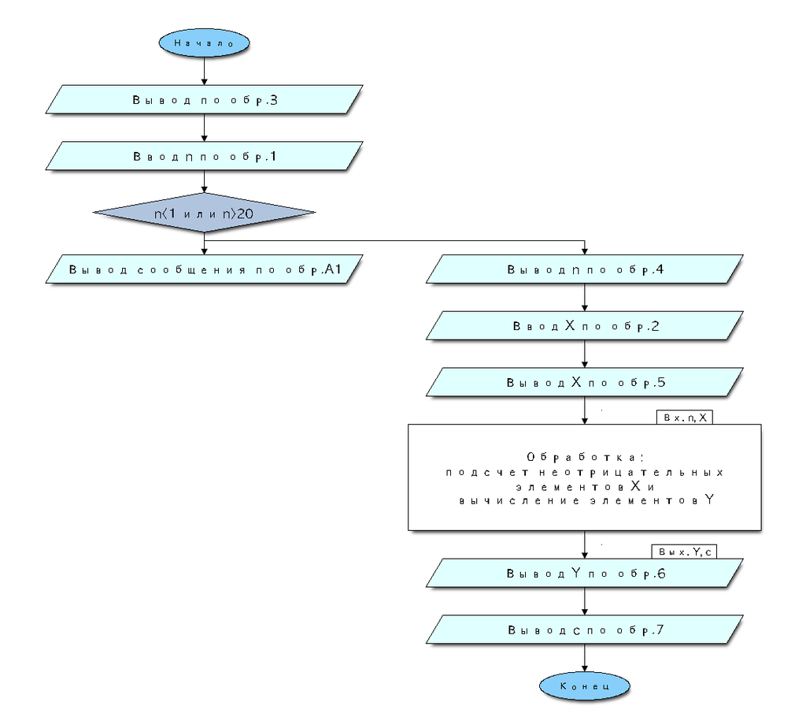

```python
from IPython.display import Image
Image("block_diagram.png")
```

### 11. Программа на *Delphi*. Диалоговый вариант {ввод с клавиатуры, вывод на экран}

Синтаксис:

[Pascal Tutorial](https://www.tutorialspoint.com/pascal/index.htm)

Проверить программу онлайн без установки программной среды:

[Compile and Execute Pascal Online](http://www.compileonline.com/compile_pascal_online.php)

```python
program Lab2; //сохранить как lab2.dpr (DPR – Delphi PRoject)
{$APPTYPE CONSOLE}
Uses Windows; // для русификации (сделать комментарием в онлайн-компиляторе!)
    const
        Nmax=20; {верх. граница индексов массива}
    var
        n, i, c: integer;
        X, Y: array [1..Nmax] of real;

    begin
        setConsoleCP(1251); // для ввода  русификация и (сделать строку комментарием в онлайн-компиляторе!)
        setConsoleOutputCP(1251); // для вывода (сделать строку комментарием в онлайн-компиляторе!)

        {A0.1 - ввод-вывод входных данных}
        writeln('Лаб.2' :40); {вывод заголовка c переходом на следующую строку по обр.3}

        writeln('Количество элементов n:'); readln(n); {ввод-вывод цел. переменной - количество элементов по обр.1,4}

        if(n<1) or (n>20) then
            if (n<1) then
                write('Некорректное n: n<1')
            else
                write('Некорректное n: n>20')
        else

        begin
            {ввод-вывод исходного массивa X по обр.2,5}
            writeln('Массив X: '); {вывод пояснения с переходом на следующую строку}
            for i:=1 to n do
            begin
                readln(X[i]); {ввод элемента и переход на следующую строку}
                writeln(X[i]:5:6);{вывод элемента и переход на следующую строку}
            end;
            for i:=1 to 80 do
                write('='); {отделим визуально чертой и строкой введенные и выводимые значения}
            writeln;

        {А0.2 - обработка, А0.3 - вывод результатов}
            c := 10; {заглушка для теста 1}
            Y[1] := 0.0; Y[2] := 0.292893; Y[3] := 1.0; Y[4] := 1.707107;{заглушка для теста 1}
            Y[5] := 2.0; Y[6] := 1.707107; Y[7] := 1.0; Y[8] := 0.5;{заглушка для теста 1}
            Y[9] := 0.292893; Y[10] := 0.133975; Y[11] := 0.0; Y[12] := 0.5;{заглушка для теста 1}
            Y[13] := 0.292893; Y[14] := 0.133975; Y[15] := 0.0; Y[16] := 0.292893;{заглушка для теста 1}
            Y[17] := 1.0; Y[18] := 1.707107; Y[19] := 2.0; Y[20] := 1.707107;{заглушка для теста 1}
//            c := 1; Y[1] := 0.0; {заглушка для теста 2}
//            c := 1; Y[1] := 0.0; Y[2] := 0.015192; Y[3] := 1.173648; Y[4] := 0.826352; {заглушка для теста 3}

            {вывод элементов массива Y по обр.6}
            writeln('Массив Y: ');
            for i:=1 to n do
            begin
                writeln(Y[i]:1:6);
            end;

            writeln('Количество неотрицательных элементов X:', c){вывод переменной по обр.7};

            write('Press Enter…'); readln; {задерживаем экран до нажатия ENTER}
        end;
    end.
```

# Раскрытие абстракции А0.2-A0.3

*Поскольку условие всей задачи совпадает (за исключением необходимости ввода) с условием выделенной подзадачи, вместо полной спецификации с пунктами 1-11 выполнено просто дополнение к пунктам 9-11.*

### 9. Метод

Пусть

- i – номер текущий точки,
- X[i] – соответствующий элемент исходного массива X,
- Y[i] – полученный по правилу (1) элемент массива Y,
- c - количество неотрицательных элементов массива X.

Присвоим переменной c начальное значение: c = 0.

При X[i] > 0 получим Y[i] = 1 - sin(X[i]). Переменная c при этом увеличивается на 1.

При X[i] ≤ 0 получим Y[i] = 1 - cos(X[i]). Переменная c при этом увеличивается на 1 только при X[i] = 0.

### 10. Алгоритм

```python
%%file block_diagram2

blockdiag {
    orientation = portrait;

    class yes [thick, label = "Да", color = blue, textcolor = blue];
    class no [thick, label = "Нет", color = red, textcolor = red];
    class start_end [shape = ellipse, fontsize = 18, color = lightskyblue];
    class input_out [shape = flowchart.input, fontsize = 18, width = 400, color = lightcyan];
    class loop_in [shape = flowchart.loopin, fontsize = 18, width = 300, color = lightsteelblue];
    class loop_out [shape = flowchart.loopout, fontsize = 18, width = 300, color = lightsteelblue];
    class condition [shape = flowchart.condition, fontsize = 18, width = 300, color = lightsteelblue];
    class command_box [shape = roundedbox, fontsize = 18, width = 300];

    Начало -> "c := 0" -> "i := 1; +1; n" -> "X[i] > 0" -> "c := c + 1", "X[i] = 0";
    "c := c + 1" -> "Y[i] := 1 - sin(X[i])";
    "X[i] = 0" -> " c := c + 1 ";
    "X[i] = 0", " c := c + 1 " -> "Y[i] := 1 - cos(X[i])";
    "Y[i] := 1 - cos(X[i])", "Y[i] := 1 - sin(X[i])" -> "Вывод Y[i] по обр.6" ->
    "i = n" -> "Вывод c по обр.7" -> Конец;
    "i = n" -> "i := 1; +1; n" [thick];

    "X[i] > 0" -> "c := c + 1" [class = 'yes'];
    "X[i] = 0" -> " c := c + 1 " [class = 'yes'];
    "X[i] > 0" -> "X[i] = 0" [class = 'no'];
    "X[i] = 0" -> "Y[i] := 1 - cos(X[i])" [class = 'no'];

    Начало, Конец [class = "start_end"];
    "i := 1; +1; n" [class = "loop_in"];
    "i = n" [class = "loop_out"];
    "X[i] > 0", "X[i] = 0" [class = "condition"];
    "Вывод Y[i] по обр.6", "Вывод c по обр.7" [class = "input_out"];
    "c := 0", "c := c + 1", " c := c + 1 " [class = "command_box"];
    "Y[i] := 1 - sin(X[i])", "Y[i] := 1 - cos(X[i])" [class = "command_box"];

     group {
         "Y[i] := 1 - sin(X[i])"; "Y[i] := 1 - cos(X[i])";
         color = lightskyblue;
   }
}
```

```
Overwriting block_diagram2
```

```python
!blockdiag block_diagram2
```

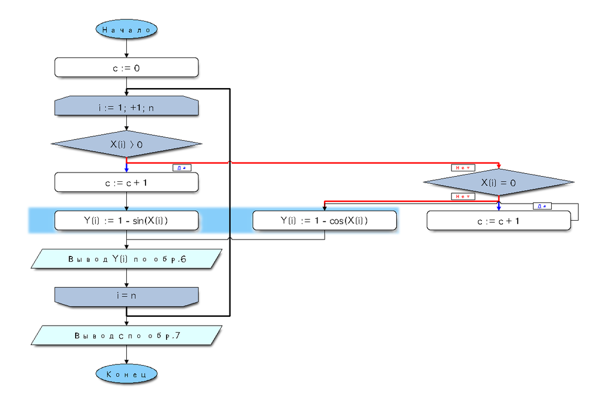

```python
Image("block_diagram2.png")
```

### 11. Программный код

```python
        {А0.2 - обработка, А0.3 - вывод результатов}
            c := 0;
            {вывод элементов массива Y по обр.6}
            writeln('Массив Y: '); {вычисление и вывод элементов массива}
            for i:=1 to n do
            begin
                if (X[i] > 0) then
                begin
                    Y[i] := 1 - sin(X[i]);
                    c := c + 1;
                end
                else
                begin
                    if (X[i] = 0) then c := c + 1;
                    Y[i] := 1 - cos(X[i]);
                end;
                writeln(Y[i]:1:6);
            end;

            writeln('Количество неотрицательных элементов X:', c){вывод переменной по обр.7};
```

# Получившиеся программы

## Лабораторная работа 3

```python
program Lab3; //сохранить как lab3.dpr (DPR – Delphi PRoject)
{$APPTYPE CONSOLE}
Uses Windows; // для русификации (сделать комментарием в онлайн-компиляторе!)
    const
        Nmax=20; {верх. граница индексов массива}
    var
        n, i, c: integer;
        X, Y: array [1..Nmax] of real;

    begin
        setConsoleCP(1251); // для ввода  русификация и (сделать строку комментарием в онлайн-компиляторе!)
        setConsoleOutputCP(1251); // для вывода (сделать строку комментарием в онлайн-компиляторе!)

        {A0.1 - ввод-вывод входных данных}
        writeln('Лаб.3' :40); {вывод заголовка c переходом на следующую строку по обр.3}

        writeln('Количество элементов n:'); readln(n); {ввод-вывод цел. переменной - количество элементов по обр.1,4}

        if(n<1) or (n>20) then
            if (n<1) then
                write('Некорректное n: n<1')
            else
                write('Некорректное n: n>20')
        else

        begin
            {ввод-вывод исходного массивa X по обр.2,5}
            writeln('Массив X: '); {вывод пояснения с переходом на следующую строку}
            for i:=1 to n do
            begin
                readln(X[i]); {ввод элемента и переход на следующую строку}
                writeln(X[i]:5:6);{вывод элемента и переход на следующую строку}
            end;
            for i:=1 to 80 do
                write('='); {отделим визуально чертой и строкой введенные и выводимые значения}
            writeln;

        {А0.2 - обработка, А0.3 - вывод результатов}
            c := 0;
            {вывод элементов массива Y по обр.6}
            writeln('Массив Y: '); {вычисление и вывод элементов массива}
            for i:=1 to n do
            begin
                if (X[i] > 0) then
                begin
                    Y[i] := 1 - sin(X[i]);
                    c := c + 1;
                end
                else
                begin
                    if (X[i] = 0) then c := c + 1;
                    Y[i] := 1 - cos(X[i]);
                end;
                writeln(Y[i]:1:6);
            end;

            writeln('Количество неотрицательных элементов X:', c){вывод переменной по обр.7};

            write('Press Enter…'); readln; {задерживаем экран до нажатия ENTER}
        end;
    end.
```

## Лабораторная работа 4

```python
program Lab4; //сохранить как lab4.dpr (DPR – Delphi PRoject)
{$APPTYPE CONSOLE}
Uses Windows; // для русификации (сделать комментарием в онлайн-компиляторе!)
    const
        Nmax=20; {верх. граница индексов массива}
    var
        n, i, c: integer;
        X, Y: array [1..Nmax] of real;
        fin, fout: TextFile; {описание файловых переменных, для работы с текстовыми файлами} // lab.4

    begin
        setConsoleCP(1251); // для ввода  русификация и (сделать строку комментарием в онлайн-компиляторе!)
        setConsoleOutputCP(1251); // для вывода (сделать строку комментарием в онлайн-компиляторе!)

        if (ParamCount<2) then // lab.4
        begin
        writeln(‘CritError: Не заданы параметры программы’);
        readln: exit;
        end;

        AssignFile(fin, ParamStr(1));      AssignFile(fout, ParamStr(2)); // lab.4
        Reset(fin); {открытие для чтения текстового файла, связанного с fin в предыдущей строке} // lab.4
        Rewrite(fout); {создание и открытие для записи файла, связанного с переменной fout} // lab.4


        {A0.1 - ввод-вывод входных данных}
        writeln(fout, 'Лаб.4' :40);  {вывод в файл заголовка c переходом на следующую строку по обр.3} // lab.4

        {ввод-вывод цел. переменной - количество элементов по обр.1,4}
        writeln(fout,'Количество элементов n:'); readln(fin, n); // lab.4

        if(n<1) or (n>20) then
            if (n<1) then
                write(fout,'Некорректное n: n<1') // lab.4
            else
                write(fout,'Некорректное n: n>20') // lab.4
        else

        begin
            {ввод-вывод исходного массивa X по обр.2,5}
            writeln(fout,'Массив X: '); {вывод пояснения с переходом на следующую строку} // lab.4
            for i:=1 to n do
            begin
                readln(fin, X[i]); {ввод элемента и переход на следующую строку} // lab.4
                writeln(fout, X[i]:5:6);{вывод элемента и переход на следующую строку} // lab.4
            end;
            {отделим визуально чертой и строкой введенные и выводимые значения}
            for i:=1 to 80 do
                write(fout, '='); // lab.4
            writeln(fout); // lab.4

        {А0.2 - обработка, А0.3 - вывод результатов}
            c := 0;
            {вывод элементов массива Y по обр.6}
            writeln(fout, 'Массив Y: '); // lab.4
            {вычисление и вывод элементов массива}
            for i:=1 to n do
            begin
                if (X[i] > 0) then
                begin
                    Y[i] := 1 - sin(X[i]);
                    c := c + 1;
                end
                else
                begin
                    if (X[i] = 0) then c := c + 1;
                    Y[i] := 1 - cos(X[i]);
                end;
                writeln(fout, Y[i]:1:6); // lab.4
            end;

            {вывод переменной по обр.7}
            writeln(fout, 'Количество неотрицательных элементов X:', c); // lab.4
        end;

        CloseFile(fin); CloseFile(fout); // lab.4

        write('Press Enter…'); readln; {задерживаем экран до нажатия ENTER}
    end.
```